# Лабораторная работа № 11

Презентация

Гайдук Софья Сергеевна

1032253645@rudn.ru

Российский университет дружбы народов

2026-04-24

## Title

# Информация

## Докладчик

- Гайдук Софья Сергеевна
- студент
- Российский университет дружбы народов им. П. Лумумбы
- 1032253645@rudn.ru
- https://github.com/SofiaGayduk/study_2025-2026_os-intro

# Цель работы

Познакомиться с операционной системой Linux. Получить практические навыки работы с редактором Emacs.

# Выполнение лабораторной работы

## Основные команды emacs

Открыть emacs ([рис. 1]).

[figure not shown]

Figure 1: image1

## Основные команды emacs

Наберить текст указанный в лабораторной работе 11 ([рис. 3]).

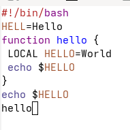

Figure 3: image3

## Основные команды emacs

Сохранить файл с помощью комбинации Ctrl-x Ctrl-s ([рис. 4]).

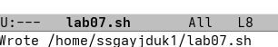

Figure 4: image4

## Основные команды emacs

Вырезать одной командой целую строку (С-k) ([рис. 5]).

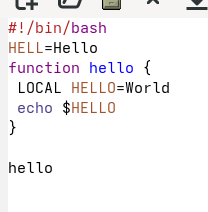

Figure 5: image5

## Основные команды emacs

Вставить эту строку в конец файла (C-y) ([рис. 6]).

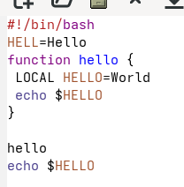

Figure 6: image6

## Основные команды emacs

Выделить область текста (C-space)([рис. 7]).

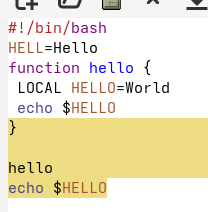

Figure 7: image7

## Основные команды emacs

Скопировать область в буфер обмена (M-w). Вставить область в конец файла ([рис. 8]).

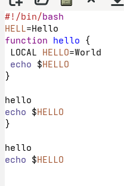

Figure 8: image8

## Основные команды emacs

Вновь выделить эту область и на этот раз вырезать её (C-w) ([рис. 9]).

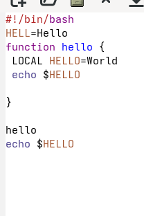

Figure 9: image9

## Основные команды emacs

Отмените последнее действие (C-/) ([рис. 10]).

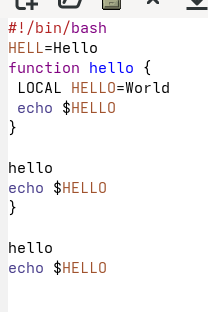

Figure 10: image10

## Основные команды emacs

Переместите курсор в начало строки (C-a) ([рис. 11]).

[figure not shown]

Figure 11: image11

## Основные команды emacs

Переместите курсор в конец строки (C-e) ([рис. 12]).

[figure not shown]

Figure 12: image12

## Основные команды emacs

Вывести список активных буферов на экран (C-x C-b) ([рис. 13]).

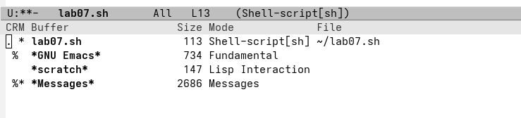

Figure 13: image13

## Основные команды emacs

Переместитесь во вновь открытое окно (C-x) o со списком открытых буферов и переключитесь на другой буфер ([рис. 14], [рис. 15]).

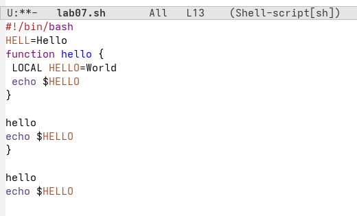

Figure 14: image14

## Основные команды emacs

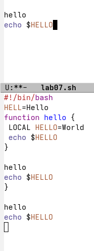

Figure 15: image15

## Основные команды emacs

Теперь вновь переключайтесь между буферами, но уже без вывода их списка на экран (C-x b) ([рис. 17]).

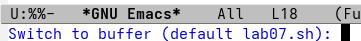

Figure 17: image17

## Основные команды emacs

Поделите фрейм на 4 части: разделите фрейм на два окна по вертикали (C-x 3), а затем каждое из этих окон на две части по горизонтали (C-x 2) ([рис. 18], [рис. 19]).

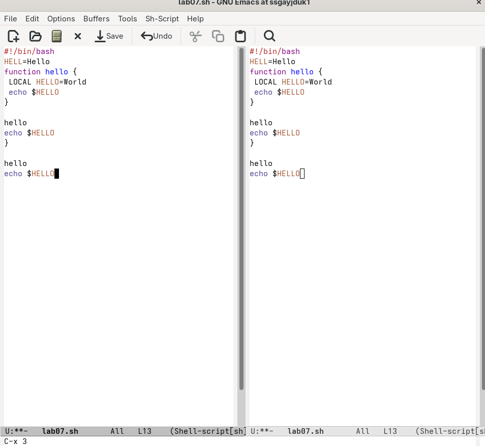

Figure 18: image18

## Основные команды emacs

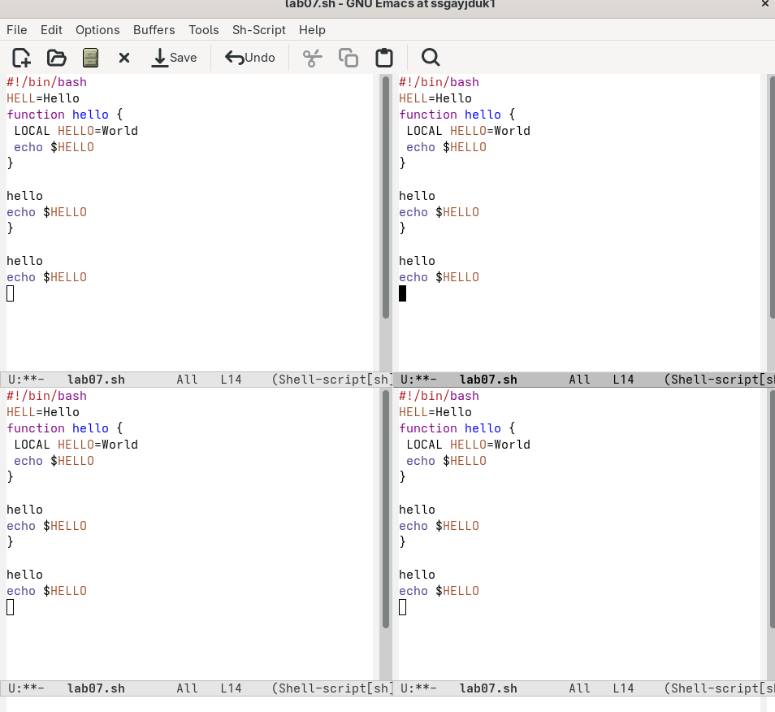

Figure 19: image19

## Основные команды emacs

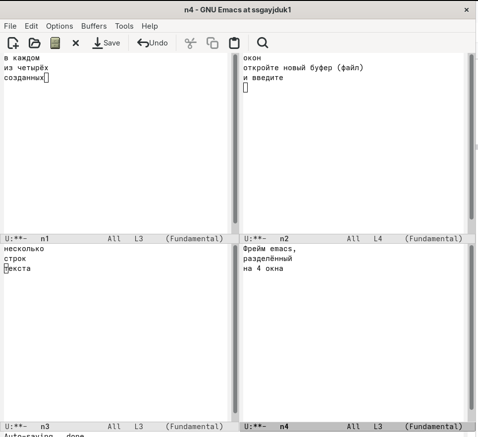

Figure 24: image24

## Основные команды emacs

Переключитесь в режим поиска (C-s), и найдите несколько слов, присутствующих в тексте, и переключайтесь между результатами поиска, нажимая C-s. После выйдите из режима поиска, нажав C-g ([рис. 25]).

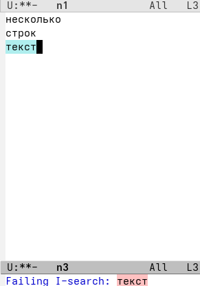

Figure 25: image25

## Основные команды emacs

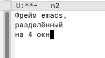

Figure 26: image26

## Основные команды emacs

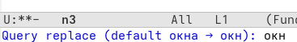

Figure 27: image27

## Основные команды emacs

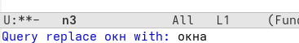

Figure 28: image28

## Основные команды emacs

Испробуйте другой режим поиска, нажав M-s o. Объясните, чем он отличается от обычного режима. В новом окне появляется строки и и выделенный текст, который подсвечивается ([рис. 30]).

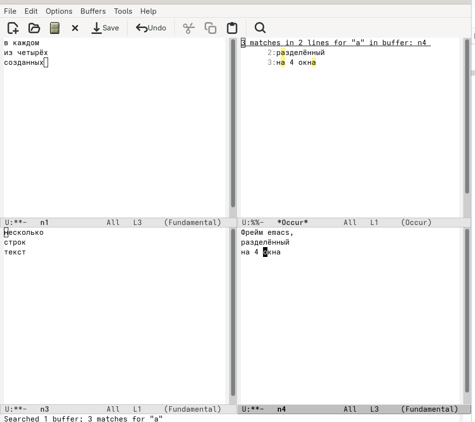

Figure 30: image30

# Выводы

Мы познакомились с операционной системой Linux. Получили практические навыки работы с редактором Emacs.

# Список литературы

1.Kulyabov. Лабораторная работа № 11. Текстовой редактор emacs. RUDN

# Список литературы

1.Kulyabov. Лабораторная работа № 11. Текстовой редактор emacs. RUDN